# Example: Federal Election Commission Database

- Adapted from *Python for Data Analysis* by Wes McKinney, O'Reilly, 2013.

> Panos Louridas, Associate Professor  
> Department of Management Science and Technology  
> Athens University of Economics and Business

# What Is It?

- The US Federal Election Commission publishes data on contributions to political campaigns.
- This includes contributor names, occupation and employer, address, and contribution amount.
- The 2012 data are available at: ftp://ftp.fec.gov/FEC/Presidential_Map/2012/P00000001/P00000001-ALL.zip.

```python
import pandas as pd
import numpy as np

import matplotlib.pyplot as plt

import matplotlib

%matplotlib inline

matplotlib.style.use('ggplot')

pd.set_option("display.max_columns", None)

data_types = {
    'cmte_id': np.str,
    'cand_id': np.str,
    'cand_nm': np.str,
    'contbr_nm': np.str,
    'contbr_city': np.str,
    'contbr_st': np.str,
    'contbr_zip': np.str,
    'contbr_employer': np.str,
    'contbr_occupation': np.str,
    'contb_receipt_amt': np.float,
    'contb_receipt_dt': np.str,
    'receipt_desc': np.str,
    'memo_cd': np.str,
    'memo_text': np.str,
    'form_tp': np.str,
    'file_num': np.str,
    'tran_id': np.str,
    'election_tp': np.str
}

fec = pd.read_csv('P00000001-ALL.csv', sep=",", index_col=False, dtype=data_types)
fec.ix[123456]
```

```
cmte_id                                      C00431171
cand_id                                      P80003353
cand_nm                                   Romney, Mitt
contbr_nm                                FENDER, MARIO
contbr_city                               NEWBURY PARK
contbr_st                                           CA
contbr_zip                                   913205237
contbr_employer                                    GPM
contbr_occupation                                SALES
contb_receipt_amt                                   25
contb_receipt_dt                             25-OCT-12
receipt_desc                                       NaN
memo_cd                                              X
memo_text            TRANSFER FROM ROMNEY VICTORY INC.
form_tp                                           SA18
file_num                                        842943
tran_id                           SA18.3903983.26.V014
election_tp                                      G2012
Name: 123456, dtype: object
```

- You can see that there are no political party affiliations in the data, so this would be useful to add.
- You can get a list of all the unique political candidates using `unique`.

```python
unique_cands = fec.cand_nm.unique()
unique_cands
```

```
array(['Bachmann, Michele', 'Romney, Mitt', 'Obama, Barack',
       "Roemer, Charles E. 'Buddy' III", 'Pawlenty, Timothy',
       'Johnson, Gary Earl', 'Paul, Ron', 'Santorum, Rick', 'Cain, Herman',
       'Gingrich, Newt', 'McCotter, Thaddeus G', 'Huntsman, Jon',
       'Perry, Rick', 'Stein, Jill'], dtype=object)
```

- An easy way to indicate party affiliation is using a `dict`.

```python
parties = {
    'Bachmann, Michele': 'Republican',
    'Romney, Mitt': 'Republican',
    'Obama, Barack': 'Democrat',
    "Roemer, Charles E. 'Buddy' III": 'Republican',
    'Pawlenty, Timothy': 'Republican',
    'Johnson, Gary Earl': 'Republican',
    'Paul, Ron': 'Republican',
    'Santorum, Rick': 'Republican',
    'Cain, Herman': 'Republican',
    'Gingrich, Newt': 'Republican',
    'McCotter, Thaddeus G': 'Republican',
    'Huntsman, Jon': 'Republican',
    'Perry, Rick': 'Republican',
    'Stein, Jill': 'Republican'
}
```

- Now, using this mapping and the `map` method on `Series` objects, we can compute an array of political parties from the candidate names.

```python
fec.cand_nm[123456:123461]
```

```
123456    Romney, Mitt
123457    Romney, Mitt
123458    Romney, Mitt
123459    Romney, Mitt
123460    Romney, Mitt
Name: cand_nm, dtype: object
```

```python
fec.cand_nm[123456:123461].map(parties)
```

```
123456    Republican
123457    Republican
123458    Republican
123459    Republican
123460    Republican
Name: cand_nm, dtype: object
```

- We can therefore add it as a column and do some counting.

```python
fec['party'] = fec.cand_nm.map(parties)
fec['party'].value_counts()
```

```
Democrat      4117404
Republican    1919054
Name: party, dtype: int64
```

- However, this includes both contributions and refunds.

```python
(fec.contb_receipt_amt > 0).value_counts()
```

```
True     5976157
False      60301
Name: contb_receipt_amt, dtype: int64
```

- So, we’ll restrict the data set to positive contributions.

```python
fec = fec[fec.contb_receipt_amt > 0]
```

- Since Barack Obama and Mitt Romney are the main two candidates, we’ll prepare a subset that has contributions to their campaigns only.

```python
fec_mrbo = fec[fec.cand_nm.isin(['Obama, Barack', 'Romney, Mitt'])]
```

## Donation Statistics by Occupation and Employer

- Donations by occupation is another oft-studied statistic.
- For example, lawyers (attorneys) tend to donate more money to Democrats, while business executives tend to donate more to Republicans.
- We can check that ourselves.
- But first let's see the overall picture.

```python
fec.contbr_occupation.value_counts()[:10]
```

```
RETIRED                                   1384118
ATTORNEY                                   194880
INFORMATION REQUESTED PER BEST EFFORTS     172528
HOMEMAKER                                  153437
PHYSICIAN                                  140700
INFORMATION REQUESTED                      125006
TEACHER                                    105486
PROFESSOR                                   96344
CONSULTANT                                  80113
ENGINEER                                    75629
Name: contbr_occupation, dtype: int64
```

- You will notice by looking at the occupations that many refer to the same basic job type, or there are several variants of the same thing.
- Here is a code snippet illustrates a technique for cleaning up a few of them by mapping from one occupation to another; note the “trick” of using `dict.get` to allow occupations with no mapping to “pass through”.

```python
occ_mapping = {
    'INFORMATION REQUESTED PER BEST EFFORTS' : 'NOT PROVIDED',
    'INFORMATION REQUESTED' : 'NOT PROVIDED',
    'INFORMATION REQUESTED (BEST EFFORTS)' : 'NOT PROVIDED',
    'C.E.O.': 'CEO'
}

# If no mapping provided, return x
f = lambda x: occ_mapping.get(x, x)
fec.contbr_occupation = fec.contbr_occupation.map(f)
```

- We'll do the same thing for employers.

```python
emp_mapping = {
    'INFORMATION REQUESTED PER BEST EFFORTS' : 'NOT PROVIDED',
    'INFORMATION REQUESTED' : 'NOT PROVIDED',
    'SELF' : 'SELF-EMPLOYED',
    'SELF EMPLOYED' : 'SELF-EMPLOYED',
}
# If no mapping provided, return x
f = lambda x: emp_mapping.get(x, x)
fec.contbr_employer = fec.contbr_employer.map(f)
```

- Now, we can use `pivot_table` to aggregate the data by party and occupation, then filter down to the subset that donated at least $2 million overall.

```python
by_occupation = fec.pivot_table(index='contbr_occupation',
                                columns='party',
                                values='contb_receipt_amt',
                                aggfunc='sum')
by_occupation
```

| party contbr_occupation | Democrat | Republican |
| --- | --- | --- |
| MIXED-MEDIA ARTIST / STORYTELLER | 100.0 | NaN |
| AREA VICE PRESIDENT | 250.0 | NaN |
| ASSISTANT MANAGER | 78.0 | NaN |
| BUILDING TECH | 78.0 | NaN |
| CAPITAL | 105.0 | NaN |
| CARPENTER | 200.0 | NaN |
| CONFLICTS MANAGER | 156.0 | NaN |
| ELDERLY PARENT CAREGIVER | 47.0 | NaN |
| EMERITA PROFESSOR AND DIRECTOR OF SOC | 262.0 | NaN |
| HISTORY PROFESSOR | 100.0 | NaN |
| JOURNALIST AND DIPLOMAT | 500.0 | NaN |
| NURSE AND TEACHER | 95.0 | NaN |
| PUBLIC HEALTH | 225.0 | NaN |
| REGISTERED NURSE | 73.0 | NaN |
| RESEARCH ASSOCIATE | 100.0 | NaN |
| RETIRED GUIDANCE COUNSELOR | 100.0 | NaN |
| RETIRED OWNER | 200.0 | NaN |
| SIMUNYE TRUST & FOUNDATION | 2400.0 | NaN |
| SOFTWARE ENGINEER/HOMEMAKER | 2225.0 | NaN |
| TEACHER | 500.0 | NaN |
| TEACHER, WRITER | 35.0 | NaN |
| TEACHER/ HOSPITAL WORKER | 96.0 | NaN |
| THERAPIST | 3900.0 | NaN |
| UNL FACULITY | 200.0 | NaN |
| VETERAN | 100.0 | NaN |
| #1 PAPER MACHINE | NaN | 100.0 |
| $200 | 91.0 | NaN |
| 'MIS MANAGER | NaN | 277.6 |
| (BUS DRIVER---DISABILITY-RETIRED) | 20.0 | NaN |
| (CAREGIVER)DIRECT SUPPORT PROFESSIONAL | 48.0 | NaN |
| ... | ... | ... |
| ZONING COMPLIANCE DEPARTMENT MANAGER | 244.0 | NaN |
| ZONING CONSULTANT | 1000.0 | NaN |
| ZONING COORDINATOR | 70.0 | NaN |
| ZONING ENFORCEMENT OFFICER | NaN | 1102.0 |
| ZONING INSPECTOR | 35.0 | NaN |
| ZONING OFFICER | 50.0 | 500.0 |
| ZONING SPECIALIST | 100.0 | NaN |
| ZOO DIRECTOR AND OWNER | NaN | 250.0 |
| ZOO KEEPER | 28.0 | NaN |
| ZOO OWNER/DIRECTOR | NaN | 500.0 |
| ZOOKEEPER | 834.0 | NaN |
| ZOOLOGIST | 995.0 | 500.0 |
| ZOOLOGY EDUCATION | 25.0 | NaN |
| ZSE | 185.0 | NaN |
| ZUMBA FITNESS INSTRUCTOR | 180.0 | NaN |
| ZUMBA GOLD INSTRUCTOR | NaN | 250.0 |
| ZUMBA INSTRUCTOR | 145.0 | 5070.0 |
| ZUMBA INSTRUCTOR AND LANDLORD | 200.0 | NaN |
| ZURICH | NaN | 200.0 |
| ZURICH NORTH AMERICA INSURANCE | NaN | 420.0 |
| [RETIRED] FACULTY | 35.0 | NaN |
| \NONE\ | NaN | 250.0 |
| \RESEARCH DIRECTOR | 250.0 | NaN |
| _ | 164.0 | NaN |
| `21` DEALER | 197.0 | NaN |
| `EXECUTIVE | 100.0 | NaN |
| `MANAGER | 35.0 | NaN |
| `TEQCHER | 106.0 | NaN |
| ``PRESIDENT | NaN | 500.0 |
| ~ | NaN | 75.0 |

142636 rows × 2 columns

- To get donations over $2 million overall, we need to sum across columns, so that we get the sum for each row.
- This is axis 1.

```python
over_2mm = by_occupation[by_occupation.sum(1) > 2000000]
over_2mm
```

| party contbr_occupation | Democrat | Republican |
| --- | --- | --- |
| ACCOUNTANT | 1363493.78 | 2.708075e+06 |
| ADMINISTRATOR | 1517360.49 | 6.795918e+05 |
| ARCHITECT | 2061397.15 | 8.117269e+05 |
| ARTIST | 2866349.53 | 7.309209e+05 |
| ATTORNEY | 34231675.63 | 2.953591e+07 |
| BANKER | 714847.90 | 4.595913e+06 |
| BUSINESS OWNER | 1316329.12 | 9.009230e+06 |
| CEO | 4067639.36 | 1.628758e+07 |
| CHAIRMAN | 779772.00 | 4.564361e+06 |
| CONSULTANT | 9002060.72 | 1.028323e+07 |
| CONTRACTOR | 304625.85 | 2.574374e+06 |
| CPA | 1053443.89 | 2.081742e+06 |
| DENTIST | 854849.24 | 2.833182e+06 |
| DIRECTOR | 1725587.90 | 1.475729e+06 |
| EDUCATOR | 1912041.70 | 3.322492e+05 |
| ENGINEER | 4980603.36 | 7.943136e+06 |
| ENTREPRENEUR | 611538.37 | 3.093882e+06 |
| EXECUTIVE | 3554006.62 | 1.664561e+07 |
| FARMER | 484164.02 | 3.508534e+06 |
| FINANCE | 971018.54 | 4.533068e+06 |
| FINANCIAL ADVISOR | 507739.54 | 2.537336e+06 |
| HOMEMAKER | 12249321.84 | 5.020739e+07 |
| INVESTMENT BANKER | 304190.45 | 2.553820e+06 |
| INVESTMENTS | 397916.70 | 3.420800e+06 |
| INVESTOR | 1718678.70 | 8.482272e+06 |
| LAWYER | 10524752.08 | 3.340725e+06 |
| MANAGEMENT | 509239.60 | 1.852110e+06 |
| MANAGER | 3556644.28 | 7.068387e+06 |
| MANAGING DIRECTOR | 627307.15 | 1.829325e+06 |
| MARKETING | 1250508.63 | 1.033953e+06 |
| NONE | 58493.92 | 1.271115e+07 |
| NOT EMPLOYED | 5775025.43 | 6.989263e+04 |
| NOT PROVIDED | 20894849.50 | 9.007606e+07 |
| OWNER | 2829168.94 | 8.934684e+06 |
| PARTNER | 895253.25 | 2.466845e+06 |
| PHYSICIAN | 15814476.62 | 2.212454e+07 |
| PRESIDENT | 4225067.26 | 1.787583e+07 |
| PROFESSOR | 11751954.25 | 1.430867e+06 |
| PSYCHOLOGIST | 2135113.82 | 2.568140e+05 |
| REAL ESTATE | 1674177.46 | 7.433708e+06 |
| REAL ESTATE DEVELOPER | 328310.00 | 1.886789e+06 |
| REALTOR | 1012712.74 | 1.492420e+06 |
| RETIRED | 98266143.94 | 1.340939e+08 |
| SALES | 1989717.96 | 6.642807e+06 |
| SCIENTIST | 1832704.15 | 3.480680e+05 |
| SELF-EMPLOYED | 2400410.01 | 1.180601e+07 |
| SMALL BUSINESS OWNER | 622918.36 | 1.717342e+06 |
| SOFTWARE ENGINEER | 2332918.45 | 1.033608e+06 |
| STUDENT | 2151467.58 | 2.472715e+06 |
| TEACHER | 6485177.65 | 1.838040e+06 |
| VICE PRESIDENT | 841578.60 | 3.182235e+06 |
| WRITER | 4201832.35 | 8.577527e+05 |

- It can be easier to look at this data graphically as a bar plot ('barh' means horizontal bar plot).

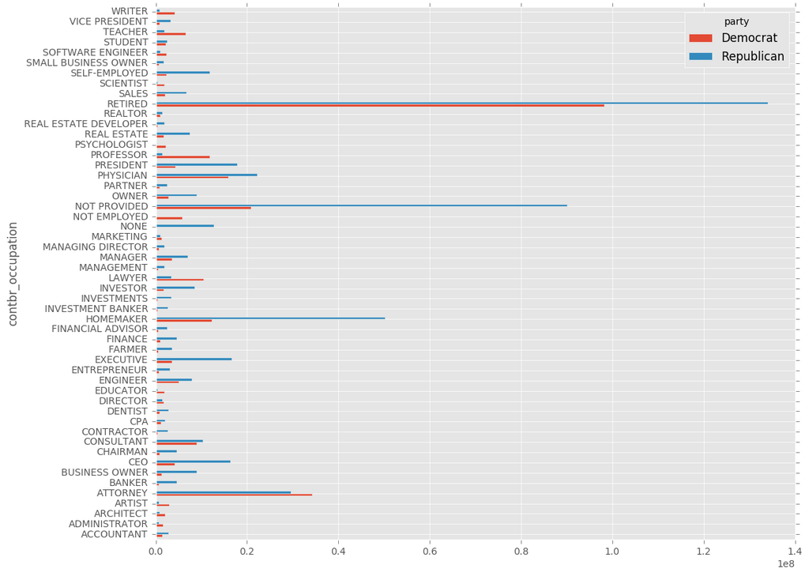

```python
ax = over_2mm.plot(kind='barh', figsize=(12, 10))
```

## Bucketing Donation Amounts

- A useful way to analyze the data is to use the `cut` function to discretize the contributor amounts into buckets by contribution size.
- First we have to define the bins.
- It is interesting to check what is going on for bin size growing logarithmically.

```python
max_contrib = fec_mrbo.ix[fec_mrbo.contb_receipt_amt.idxmax()]
max_contrib
```

```
cmte_id                                         C00431445
cand_id                                         P80003338
cand_nm                                     Obama, Barack
contbr_nm            OBAMA VICTORY FUND 2012 - UNITEMIZED
contbr_city                                       CHICAGO
contbr_st                                              IL
contbr_zip                                          60680
contbr_employer                                       NaN
contbr_occupation                                     NaN
contb_receipt_amt                             1.63872e+07
contb_receipt_dt                                28-SEP-12
receipt_desc                                          NaN
memo_cd                                                 X
memo_text                                               *
form_tp                                              SA18
file_num                                           821325
tran_id                                        CZ22557505
election_tp                                         G2012
party                                            Democrat
Name: 3280428, dtype: object
```

```python
bins = np.logspace(0, 8, num=9)
bins = np.insert(bins, 0, 0)
bins
```

```
array([  0.00000000e+00,   1.00000000e+00,   1.00000000e+01,
         1.00000000e+02,   1.00000000e+03,   1.00000000e+04,
         1.00000000e+05,   1.00000000e+06,   1.00000000e+07,
         1.00000000e+08])
```

```python
bin_labels = pd.cut(fec_mrbo.contb_receipt_amt, bins)
bin_labels
```

```
411          (100, 1000]
412            (10, 100]
413          (100, 1000]
414          (100, 1000]
415          (100, 1000]
416          (100, 1000]
417            (10, 100]
418          (100, 1000]
419          (100, 1000]
420            (10, 100]
421            (10, 100]
422            (10, 100]
423          (100, 1000]
424            (10, 100]
425          (100, 1000]
```

[output cut: 48 more lines]

- We can then group the data for Obama and Romney by name and bin label to get a histogram by donation size.

```python
grouped = fec_mrbo.groupby(['cand_nm', bin_labels])
grouped.size().unstack()
```

| contb_receipt_amt cand_nm | (0, 1] | (1, 10] | (10, 100] | (100, 1000] | (1000, 10000] | (10000, 100000] | (100000, 1000000] | (1000000, 10000000] | (10000000, 100000000] |
| --- | --- | --- | --- | --- | --- | --- | --- | --- | --- |
| Obama, Barack | 1199.0 | 402595.0 | 2970577.0 | 651166.0 | 53379.0 | 7.0 | 4.0 | 17.0 | 1.0 |
| Romney, Mitt | 582.0 | 38335.0 | 749228.0 | 633364.0 | 154963.0 | 6.0 | NaN | NaN | NaN |

- The data shows that Obama has received a significantly larger number of small donations than Romney.
- We can also sum the contribution amounts and normalize within buckets to visualize the percentage of total donations of each size by candidate.
- We first do the sums.

```python
bucket_sums = grouped.contb_receipt_amt.sum().unstack(0)
bucket_sums
```

| cand_nm contb_receipt_amt | Obama, Barack | Romney, Mitt |
| --- | --- | --- |
| (0, 1] | 7.379000e+02 | 5.758100e+02 |
| (1, 10] | 3.349061e+06 | 2.875624e+05 |
| (10, 100] | 1.441489e+08 | 4.747309e+07 |
| (100, 1000] | 2.214402e+08 | 2.581337e+08 |
| (1000, 10000] | 1.187649e+08 | 3.739610e+08 |
| (10000, 100000] | 2.171000e+05 | 1.390000e+05 |
| (100000, 1000000] | 1.658333e+06 | NaN |
| (1000000, 10000000] | 5.239269e+07 | NaN |
| (10000000, 100000000] | 1.638718e+07 | NaN |

- Then we can do the normalization.

```python
normed_sums = bucket_sums.div(bucket_sums.sum(axis=1), axis=0)
normed_sums
```

| cand_nm contb_receipt_amt | Obama, Barack | Romney, Mitt |
| --- | --- | --- |
| (0, 1] | 0.561692 | 0.438308 |
| (1, 10] | 0.920926 | 0.079074 |
| (10, 100] | 0.752257 | 0.247743 |
| (100, 1000] | 0.461744 | 0.538256 |
| (1000, 10000] | 0.241036 | 0.758964 |
| (10000, 100000] | 0.609660 | 0.390340 |
| (100000, 1000000] | 1.000000 | NaN |
| (1000000, 10000000] | 1.000000 | NaN |
| (10000000, 100000000] | 1.000000 | NaN |

- And here is a plot of the last table.

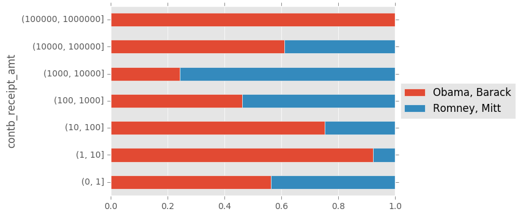

```python
f = plt.figure()
normed_sums[:-2].plot(kind='barh', stacked=True, ax=f.gca())
plt.legend(loc='center left', bbox_to_anchor=(1.0, 0.5))
```

## How Did They Do Overall?

- Now, let's see how the two presidential candidates fared overall.
- How much money did they raise?

```python
fec_mrbo.groupby('cand_nm').sum()
```

| cand_nm | contb_receipt_amt |
| --- | --- |
| Obama, Barack | 5.583591e+08 |
| Romney, Mitt | 6.799949e+08 |

```python
fec.ix[123456]
```

```
cmte_id                                      C00431171
cand_id                                      P80003353
cand_nm                                   Romney, Mitt
contbr_nm                                FENDER, MARIO
contbr_city                               NEWBURY PARK
contbr_st                                           CA
contbr_zip                                   913205237
contbr_employer                                    GPM
contbr_occupation                                SALES
contb_receipt_amt                                   25
contb_receipt_dt                             25-OCT-12
receipt_desc                                       NaN
memo_cd                                              X
memo_text            TRANSFER FROM ROMNEY VICTORY INC.
form_tp                                           SA18
file_num                                        842943
tran_id                           SA18.3903983.26.V014
election_tp                                      G2012
party                                       Republican
Name: 123456, dtype: object
```

- This is actually a transfer *from* Romney *to* Romney.
- How many such transfers are there?

```python
transfers = fec[fec['memo_text'].str.contains("TRANSFER").fillna(False)]

mr_transfers = transfers[transfers['cand_nm'] == 'Romney, Mitt']
bo_transfers = transfers[transfers['cand_nm'] == 'Obama, Barack']
print("Romney -> Romney:", mr_transfers['contb_receipt_amt'].count(), mr_transfers['contb_receipt_amt'].sum())
print("Obama -> Obama:", bo_transfers['contb_receipt_amt'].count(), bo_transfers['contb_receipt_amt'].sum())
```

```
Romney -> Romney: 644022 295380725.37
Obama -> Obama: 0 0
```

- So, there are *lots* of transfers from Romney to Romney.
- We had better remove them.

```python
fec = fec[~fec['memo_text'].str.contains("TRANSFER").fillna(False)]

fec_mrbo = fec[fec.cand_nm.isin(['Obama, Barack', 'Romney, Mitt'])]

fec_mrbo.groupby('cand_nm').sum()
```

| cand_nm | contb_receipt_amt |
| --- | --- |
| Obama, Barack | 5.583591e+08 |
| Romney, Mitt | 3.846142e+08 |

- This is better than before, but more than what has been reported.
- Part of it may be explained by other records with indicative `memo_text` contents.

```python
fec[fec.cand_nm=='Romney, Mitt'].memo_text.unique()
```

```
array([nan, 'SEE REATTRIBUTION', 'REATTRIBUTION FROM SPOUSE',
       'REATTRIBUTED TO SPOUSE ON 8/3/2012', 'REDESIGNATION FROM PRIMARY',
       'REDESIGNATION FROM GENERAL', 'REFUND TO BE ISSUED',
       'EARMARK: ACTRIGHT.COM PAC', 'ATTRIBUTION TO PARTNERS REQUESTED',
       'REATTRIBUTION / REDESIGNATION REQUESTED',
       'IN-KIND: EVENT SUPPLIES', 'PARTNER ATTRIBUTION',
       'EARMARK: ACTRIGHT', 'REFUNDED $150.00 ON 06/07/2012',
       'REATTRIBUTION REQUESTED', 'REFUNDED $6.00 ON 11/16/2011',
       'REFUNDED $165.43 ON 12/06/2011',
       'CHARGED BACK $1000.00 ON 07/10/2012',
       'CHARGED BACK $1197.00 ON 09/26/2012',
       'CHARGED BACK $100.00 ON 11/19/2012',
       'JOINT FUNDRAISING REALLOCATION PENDING',
       'IN-KIND: MEETING EXPENSE AND OFFICE SUPPLIES REFUNDED $682.45 ON 11/20/2012',
       'REFUNDED $1500.00 ON 10/08/2012',
       'IN-KIND: AUDIO VISUAL SERVICES/PRINTING & DESIGN SERVICES REFUNDED $522.32 ON 10/16/2012',
       'CHARGED BACK $2555.00 ON 11/05/2012',
       'REDESIGNATION FROM GENERAL; CHARGED BACK $2500.00 ON 11/06/2012',
       'CHARGED BACK $1000.00 ON 10/29/2012',
       'REDESIGNATION FROM GENERAL; REFUND TO BE ISSUED',
       'EARMARK:  ACTRIGHT.COM PAC', 'EARMARK: ACTRIGHT PAC',
       'REFUNDED $37.00 ON 07/25/2012', 'REFUNDED $4500.00 ON 09/26/2012',
       'CHARGED BACK $400.00 ON 09/26/2012',
       'EARMARK: ACTRIGHT; DONATION MADE TO ACTRIGHT PRIOR TO GENERAL ELECTION',
       'CHARGED BACK $2500.00 ON 06/22/2011', 'EARMARK: CLUB FOR GROWTH',
       'CHARGED BACK $5000.00 ON 09/26/2012',
       'CHARGED BACK $250.00 ON 10/17/2012',
       'REFUNDED $25.00 ON 07/15/2011',
       'CHARGED BACK $45.00 ON 07/26/2011',
       'REFUNDED $2500.00 ON 09/06/2011',
       'ATTRIBUTION TO PARTNERS REQUESTED / REDESIGNATION REQUESTED',
       'REFUNDED $5.00 ON 12/19/2011', 'REFUNDED $93.00 ON 12/12/2011',
       'REFUNDED $266.00 ON 03/07/2012', 'REFUNDED $1000.00 ON 02/24/2012',
       'REFUNDED $140.00 ON 01/23/2012',
       'CHARGED BACK $1000.00 ON 06/08/2012',
       'REFUNDED $2475.00 ON 08/16/2012',
       'REFUNDED $5000.00 ON 08/16/2012',
       'REATTRIBUTION / REDESIGNATION REQUESTED; REFUND TO BE ISSUED',
       'REFUNDED $1500.00 ON 08/24/2012', 'REFUNDED $50.00 ON 08/16/2012',
       'EARMARK: ACTRIGHT.COM PAC; REDESIGNATION FROM PRIMARY',
```

[output cut: 533 more lines]

```
       'IN-KIND: OFFICE SUPPLIES; REFUNDED $19.42 ON 07/25/2012',
       'IN-KIND: OFFICE SUPPLIES; REFUNDED $71.06 ON 07/25/2012',
       'IN-KIND: EVENT STAGING EXPENSE REFUNDED $638.50 ON 09/19/2012',
       'IN-KIND: FACILITY RENTAL/CATERING SERVICES REFUNDED $858.42 ON 09/25/2012',
       'IN-KIND: OFFICE SUPPLIES REFUNDED $56.84 ON 09/19/2012',
       'EARMARK: REALTORS DIRECT GIVER PROGRAM',
       'EARMARK: THE REINHART PROGESS FUND',
       'EARMARK: AGC OF WISCONSIN CONDUIT',
       'EARMARK: REPUBLICAN PARTY OF WAUKESHA COUNTY',
       'IN-KIND: FACILITY RENTAL/CATERING SERVICES REFUNDED $421.36 ON 08/30/2012',
       'IN-KIND: FOOD & BEVERAGES REFUNDED $241.52 ON 08/06/2012',
       'IN-KIND: EVENT STAGING EXPENSE REFUNDED $240.86 ON 08/30/2012',
       'REFUNDED $100.00 ON 11/29/2011', 'REFUNDED $2000.00 ON 08/26/2011',
       'REFUNDED $5000.00 ON 08/29/2011',
       'CHARGED BACK $30000.00 ON 06/21/2012'], dtype=object)
```

```python
fec[fec.memo_text=='REFUNDED $1985.00 ON 10/18/2011']
```

|  | cmte_id | cand_id | cand_nm | contbr_nm | contbr_city | contbr_st | contbr_zip | contbr_employer | contbr_occupation | contb_receipt_amt | contb_receipt_dt | receipt_desc | memo_cd | memo_text | form_tp | file_num | tran_id | election_tp | party |
| --- | --- | --- | --- | --- | --- | --- | --- | --- | --- | --- | --- | --- | --- | --- | --- | --- | --- | --- | --- |
| 1000629 | C00431171 | P80003353 | Romney, Mitt | MAIELLO, FRANK MR. | LYNBROOK | NY | 115632002 | NONE | RETIRED | 2005.0 | 13-OCT-11 | NaN | NaN | REFUNDED $1985.00 ON 10/18/2011 | SA17A | 809153 | SA17.653587 | P2012 | Republican |

## Donation Statistics by Occupation and Employee (2)

- Let's redo the stats with the data partially cleaned.

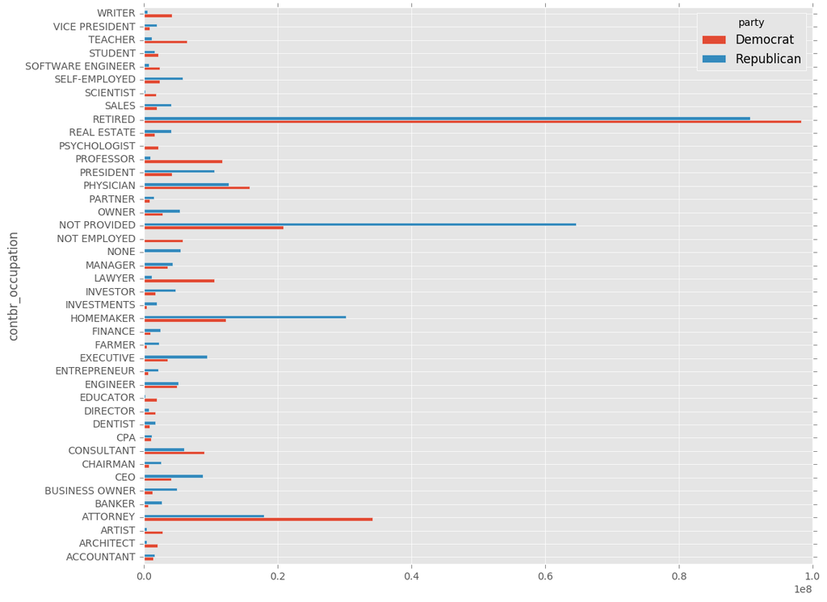

```python
by_occupation = fec.pivot_table(index='contbr_occupation',
                                columns='party',
                                values='contb_receipt_amt',
                                aggfunc='sum')
over_2mm = by_occupation[by_occupation.sum(1) > 2000000]
ax = over_2mm.plot(kind='barh', figsize=(12, 10))
```

## Bucketing Donation Amounts (2)

```python
fec_mrbo = fec[fec.cand_nm.isin(['Obama, Barack', 'Romney, Mitt'])]
max_contrib = fec_mrbo.ix[fec_mrbo.contb_receipt_amt.idxmax()]
max_contrib
```

```
cmte_id                                         C00431445
cand_id                                         P80003338
cand_nm                                     Obama, Barack
contbr_nm            OBAMA VICTORY FUND 2012 - UNITEMIZED
contbr_city                                       CHICAGO
contbr_st                                              IL
contbr_zip                                          60680
contbr_employer                                       NaN
contbr_occupation                                     NaN
contb_receipt_amt                             1.63872e+07
contb_receipt_dt                                28-SEP-12
receipt_desc                                          NaN
memo_cd                                                 X
memo_text                                               *
form_tp                                              SA18
file_num                                           821325
tran_id                                        CZ22557505
election_tp                                         G2012
party                                            Democrat
Name: 3280428, dtype: object
```

```python
bin_labels = pd.cut(fec_mrbo.contb_receipt_amt, bins)
grouped = fec_mrbo.groupby(['cand_nm', bin_labels])
grouped.size().unstack()
```

| contb_receipt_amt cand_nm | (0, 1] | (1, 10] | (10, 100] | (100, 1000] | (1000, 10000] | (10000, 100000] | (100000, 1000000] | (1000000, 10000000] | (10000000, 100000000] |
| --- | --- | --- | --- | --- | --- | --- | --- | --- | --- |
| Obama, Barack | 1199.0 | 402595.0 | 2970577.0 | 651166.0 | 53379.0 | 7.0 | 4.0 | 17.0 | 1.0 |
| Romney, Mitt | 393.0 | 13934.0 | 428395.0 | 411637.0 | 78091.0 | 6.0 | NaN | NaN | NaN |

```python
bucket_sums = grouped.contb_receipt_amt.sum().unstack(0)
bucket_sums
```

| cand_nm contb_receipt_amt | Obama, Barack | Romney, Mitt |
| --- | --- | --- |
| (0, 1] | 7.379000e+02 | 3.900400e+02 |
| (1, 10] | 3.349061e+06 | 1.143761e+05 |
| (10, 100] | 1.441489e+08 | 2.886292e+07 |
| (100, 1000] | 2.214402e+08 | 1.624248e+08 |
| (1000, 10000] | 1.187649e+08 | 1.930727e+08 |
| (10000, 100000] | 2.171000e+05 | 1.390000e+05 |
| (100000, 1000000] | 1.658333e+06 | NaN |
| (1000000, 10000000] | 5.239269e+07 | NaN |
| (10000000, 100000000] | 1.638718e+07 | NaN |

```python
normed_sums = bucket_sums.div(bucket_sums.sum(axis=1), axis=0)
normed_sums
```

| cand_nm contb_receipt_amt | Obama, Barack | Romney, Mitt |
| --- | --- | --- |
| (0, 1] | 0.654201 | 0.345799 |
| (1, 10] | 0.966976 | 0.033024 |
| (10, 100] | 0.833174 | 0.166826 |
| (100, 1000] | 0.576870 | 0.423130 |
| (1000, 10000] | 0.380855 | 0.619145 |
| (10000, 100000] | 0.609660 | 0.390340 |
| (100000, 1000000] | 1.000000 | NaN |
| (1000000, 10000000] | 1.000000 | NaN |
| (10000000, 100000000] | 1.000000 | NaN |

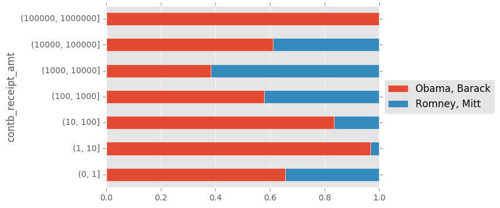

```python
f = plt.figure()
normed_sums[:-2].plot(kind='barh', stacked=True, ax=f.gca())
plt.legend(loc='center left', bbox_to_anchor=(1.0, 0.5))
```